## 5. Simulations and HMM estimations

#### Simulating and estimating for 100 loci

recombination rate = 0.3

```r
start.p<-c(0.25,0.25,0.25,0.25)
recombination.rate<-0.3
trans.p<-GetTransitionProb(recombination.rate)
child1.chromatid.mom<-SimulateChromatid(100,recombination.rate) #100 markers
child1.chromatid.dad<-SimulateChromatid(100,recombination.rate)
obs<-child1.chromatid.mom$child+child1.chromatid.dad$child
v.2<-Viterbi2 (obs,start.p, trans.p,child1.chromatid.mom,child1.chromatid.dad)
vitrowmax.2 <- apply(v.2, 1, function(x) which.max(x))
vitrowmax.2
```

```
##   [1] 1 1 2 1 1 1 2 2 2 2 2 2 2 2 1 2 2 2 2 1 1 1 3 3 3 3 3 3 4 4 2 2 1 4 4
##  [36] 4 4 4 4 4 4 4 3 1 3 3 3 1 1 2 2 1 1 3 3 4 4 4 3 1 2 2 1 1 1 1 2 2 4 3
##  [71] 3 1 4 4 3 1 1 1 1 1 2 1 1 2 2 3 3 3 3 1 1 1 2 2 2 4 4 4 4 4
```

```r
simulated<-paste("mom.",child1.chromatid.mom$parent.path,"/","dad.",child1.chromatid.dad$parent.path,sep="")
estimated<-rownames(trans.p)[vitrowmax.2]
sim.results<-sum(simulated==estimated)
```

The number for true positives from our estimation would be given by.

```r
sum(sim.results)
```

```
## [1] 57
```

and the percentage of true positives is 57%

#### Simulating for 10,000 loci and recombination rate r=0.3

```r
child1.chromatid.mom<-SimulateChromatid(10000,recombination.rate) #100 markers
child1.chromatid.dad<-SimulateChromatid(10000,recombination.rate)
obs<-child1.chromatid.mom$child+child1.chromatid.dad$child
v.2<-Viterbi2 (obs,start.p, trans.p,child1.chromatid.mom,child1.chromatid.dad)
vitrowmax.2 <- apply(v.2, 1, function(x) which.max(x))
simulated<-paste("mom.",child1.chromatid.mom$parent.path,"/","dad.",child1.chromatid.dad$parent.path,sep="")
estimated<-rownames(trans.p)[vitrowmax.2]
sim.results<-sum(simulated==estimated)
sum(sim.results)
```

```
## [1] 2686
```

and the percentage of true positives is 26.86%. Much lower than when we simulated for 100 loci. Let’s look at some values of our matrix returned by Viterbi2 to see what is the problem.

```r
v.2[1:5,]
```

```
##             [,1] [,2]        [,3]     [,4]
## [1,] 0.000000000 0.25 0.250000000 0.000000
## [2,] 0.052500000 0.00 0.122500000 0.000000
## [3,] 0.000000000 0.00 0.000000000 0.025725
## [4,] 0.002315250 0.00 0.005402250 0.000000
## [5,] 0.001134472 0.00 0.002647102 0.000000
```

```r
v.2[1500:1505,]
```

```
##      [,1] [,2] [,3] [,4]
## [1,]    0    0    0    0
## [2,]    0    0    0    0
## [3,]    0    0    0    0
## [4,]    0    0    0    0
## [5,]    0    0    0    0
## [6,]    0    0    0    0
```

```r
v.2[5000:5005,]
```

```
##      [,1] [,2] [,3] [,4]
## [1,]    0    0    0    0
## [2,]    0    0    0    0
## [3,]    0    0    0    0
## [4,]    0    0    0    0
## [5,]    0    0    0    0
## [6,]    0    0    0    0
```

```r
v.2[9000:9005,]
```

```
##      [,1] [,2] [,3] [,4]
## [1,]    0    0    0    0
## [2,]    0    0    0    0
## [3,]    0    0    0    0
## [4,]    0    0    0    0
## [5,]    0    0    0    0
## [6,]    0    0    0    0
```

As you can see, the values get smaller to the point R does not have a representation and shows 0. To prevent this we can modify our Viterbi2 algorythm to use the log2 of the probabilities instead.

```r
Viterbi3 <- function(obs,start.p, trans.p,mom.chromatid,dad.chromatid) {
  #initializing
  v <- matrix(NA, nr=length(obs), nc=dim(trans.p)[1])
  emit.p<-GetEmissionProb(mom.chromatid$maternal[1],
                          mom.chromatid$paternal[1],
                          dad.chromatid$maternal[1],
                          dad.chromatid$paternal[1])
  emit.p<-emit.p+10^(-12)
  for(i in 1:4){
    v[1,i]=log(start.p[i],2)+log(emit.p[i,obs[1]+1],2)
  }

  for(i in 2:length(obs)) {# from observation 2 to t
     emit.p<-GetEmissionProb(mom.chromatid$maternal[i],
                             mom.chromatid$paternal[i],
                             dad.chromatid$maternal[i],
                             dad.chromatid$paternal[i])
     for (l in 1:dim(trans.p)[1]) { #from state 1 to N (4 states)
       v[i,l] <- log(emit.p[l,obs[i]+1]+10^(-12),2) + max(v[(i-1),] + log( trans.p[l,],2))
     }
  }

  return(v)
}
```

You will notice that I am adding +10^(-12) before using the value from the emission matrix. We are doing that because we don’t want to calculate the log2 of 0 which would be -Inf.

```r
child1.chromatid.mom<-SimulateChromatid(10000,recombination.rate) #100 markers
child1.chromatid.dad<-SimulateChromatid(10000,recombination.rate)
obs<-child1.chromatid.mom$child+child1.chromatid.dad$child
v.2<-Viterbi3 (obs,start.p, trans.p,child1.chromatid.mom,child1.chromatid.dad)
vitrowmax.2 <- apply(v.2, 1, function(x) which.max(x))
simulated<-paste("mom.",child1.chromatid.mom$parent.path,"/","dad.",child1.chromatid.dad$parent.path,sep="")
estimated<-rownames(trans.p)[vitrowmax.2]
sim.results<-sum(simulated==estimated)
sum(sim.results)
```

```
## [1] 5966
```

and the percentage of true positives is 59.66%. Closer to what we got when simulated for 100 loci. Now that our Viterbi function is more robust we can do more simulations.

#### A lot of simulations

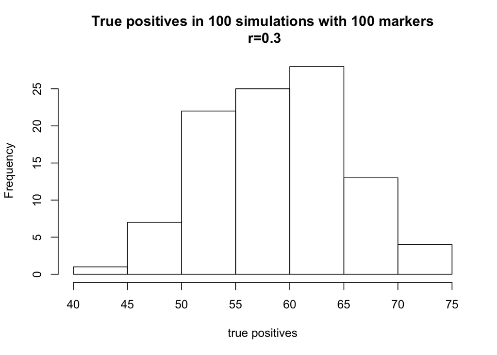

```r
start.p<-c(0.25,0.25,0.25,0.25)

ViterbiSimulator <- function(num.markers,num.simulations,start.p,recombination.rate){
  sim.results<-c()
  trans.p<-GetTransitionProb(recombination.rate)
  for (i in 1:num.simulations){
    child1.chromatid.mom<-SimulateChromatid(num.markers,recombination.rate) #100 markers
    child1.chromatid.dad<-SimulateChromatid(num.markers,recombination.rate)
    obs<-child1.chromatid.mom$child+child1.chromatid.dad$child
    v.2<-Viterbi3 (obs,start.p, trans.p,child1.chromatid.mom,child1.chromatid.dad)
    vitrowmax.2 <- apply(v.2, 1, function(x) which.max(x))
    simulated<-paste("mom.",child1.chromatid.mom$parent.path,"/","dad.",child1.chromatid.dad$parent.path,sep="")
    estimated<-rownames(trans.p)[vitrowmax.2]
    sim.results[i]<-sum(simulated==estimated)
  }
  return(sim.results)
}

result.100.03<-ViterbiSimulator(100,100,start.p,0.3);
hist(result.100.03,main="True positives in 100 simulations with 100 markers\n r=0.3",xlab="true positives")
```

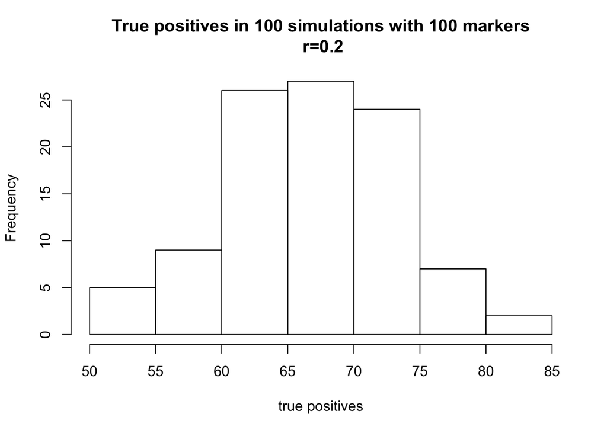

```r
result.100.02<-ViterbiSimulator(100,100,start.p,0.2);
hist(result.100.02,main="True positives in 100 simulations with 100 markers\n r=0.2",xlab="true positives")
```

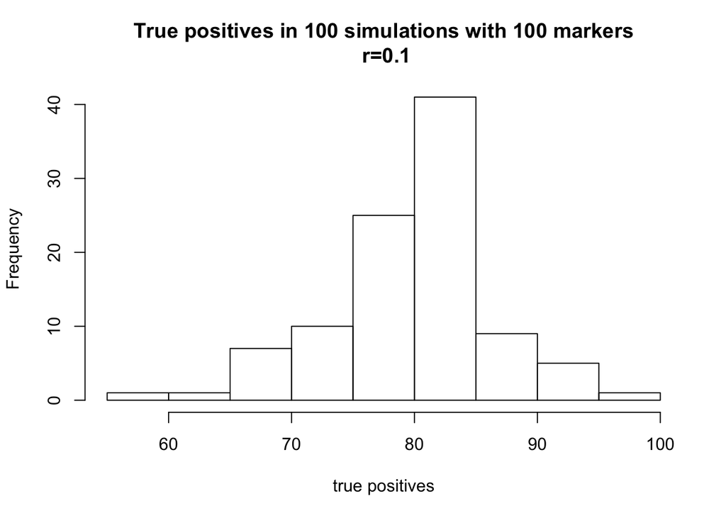

```r
result.100.01<-ViterbiSimulator(100,100,start.p,0.1);
hist(result.100.01,main="True positives in 100 simulations with 100 markers\n r=0.1",xlab="true positives")
```

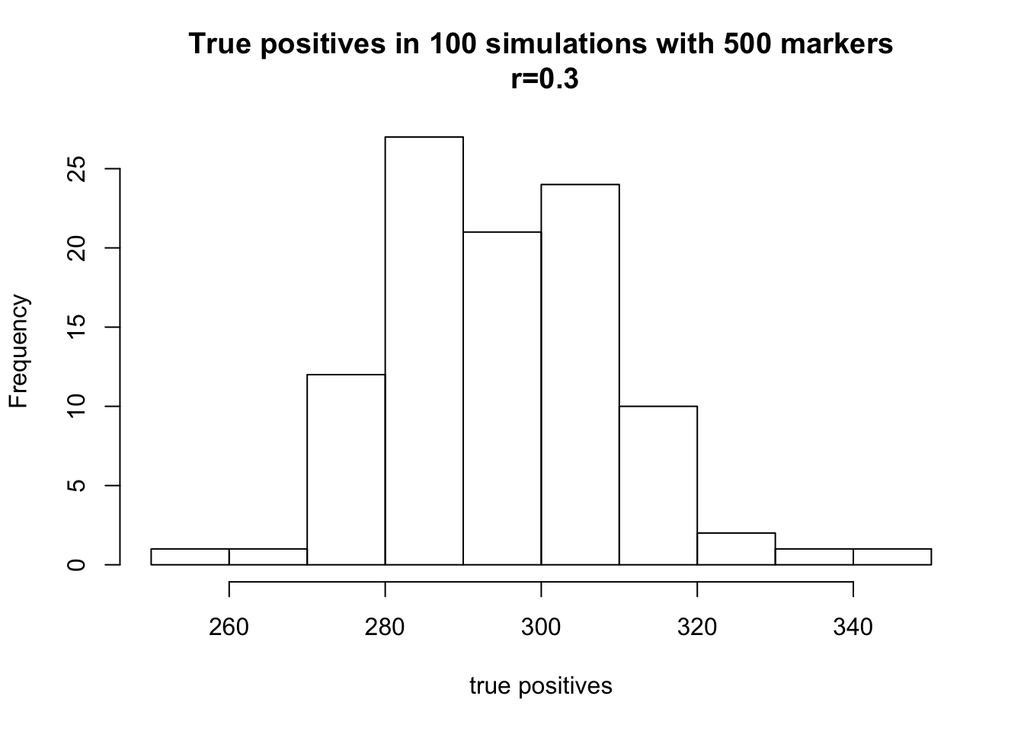

```r
result.500.03<-ViterbiSimulator(500,100,start.p,0.3)
result.500.02<-ViterbiSimulator(500,100,start.p,0.2)
result.500.01<-ViterbiSimulator(500,100,start.p,0.1)

hist(result.500.03,main="True positives in 100 simulations with 500 markers\n r=0.3",xlab="true positives")
```

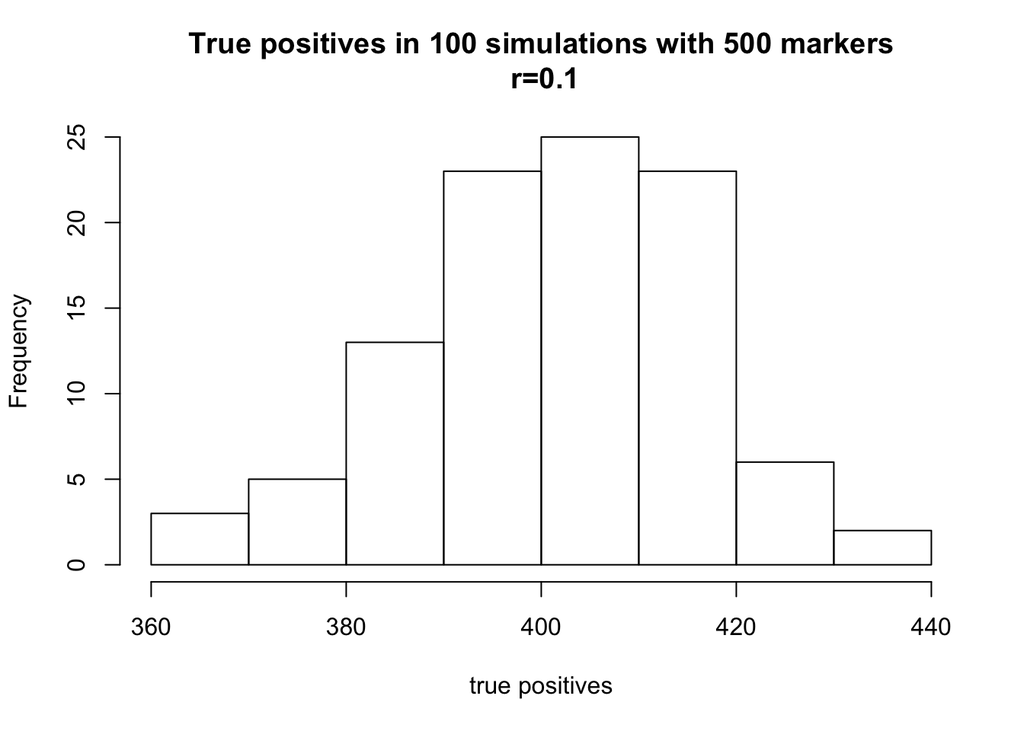

```r
hist(result.500.01,main="True positives in 100 simulations with 500 markers\n r=0.1",xlab="true positives")
```

#### Percent mean true positives for estimations of different recombination rates and number of loci

[output not shown]

From these results it is clear that our estimation accuracy increases with smaller recombination rates and it appears to be independent from the number of loci.

#### Author

Luis Avila (lmavila@gmail.com)